# Structural VARs

Module 11 · The equations are real but the parameters don’t matter.

Gary Cornwall

Econ 6376 · The George Washington University

# Act I · The equations are real

What changes when both variables respond?

## Where we are: give the predictor an equation

C02 · Module 8’s ARDL → a connected system

$$y_t=\alpha+\phi_1y_{t-1}+\beta_0x_t+\beta_1x_{t-1}+\epsilon_t$$

| Mixing-board channel | Today |
| --- | --- |
| Own memory | Keep one lag |
| Cross-variable history | Let both outcomes depend on it |
| Current connections | Allow reciprocal dependence |
| Equations | Give **each outcome** its own equation |

Module 10 let two variables adjust. What if we model both current outcomes together?

## One disturbance, a connected pond

C03 · Disturbance location ≠ observed movement

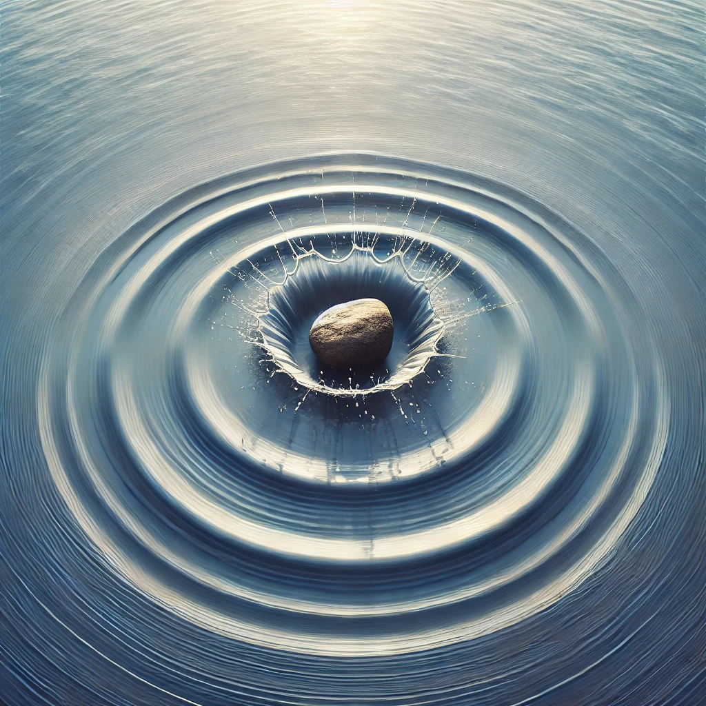

A stone disturbs a connected body of water.

A disturbance starts somewhere.

Connections transmit it elsewhere.

Does movement at a second point tell us where the stone entered?

Think about inflation and the policy rate.

## The ARDL already had a current connection

C04 · One conditional outcome

[figure not shown]

Dated graph: past y and x and current x enter current y; current x has no supplied equation.

$$y_t=\alpha+\phi_1y_{t-1}$$
$$\quad+\beta_0x_t+\beta_1x_{t-1}+\epsilon_t$$

Which current variable still lacks an equation?

## Give current x its own equation

C05 · A second outcome, the same history

[figure not shown]

Both current outcomes now receive arrows from yesterday’s y and x; current x still enters y.

$$y_t=\alpha_y+b_{yx}x_t$$
$$\quad+\phi_{yy}y_{t-1}+\phi_{yx}x_{t-1}+\eta_{y,t}$$
$$x_t=\alpha_x+\phi_{xy}y_{t-1}$$
$$\quad+\phi_{xx}x_{t-1}+\eta_{x,t}$$

Which terms record the new arrows?

## Turn on reciprocal current dependence

C06 · The new term creates a current cycle

[figure not shown]

Separate current arrows x to y and y to x form a directed cycle.

$$y_t=\alpha_y+b_{yx}x_t$$
$$\quad+\phi_{yy}y_{t-1}+\phi_{yx}x_{t-1}+\eta_{y,t}$$
$$x_t=\alpha_x+\underbrace{b_{xy}y_t}_{\text{new current connection}}$$
$$\quad+\phi_{xy}y_{t-1}+\phi_{xx}x_{t-1}+\eta_{x,t}$$

Can we calculate either current value without the other?

## Read the structural pair

C07 · First subscript: receiving equation · second: entering variable

$$\begin{aligned}
y_t&=\alpha_y+b_{yx}x_t+\phi_{yy}y_{t-1}+\phi_{yx}x_{t-1}+\eta_{y,t},\\[.5em]
x_t&=\alpha_x+b_{xy}y_t+\phi_{xy}y_{t-1}+\phi_{xx}x_{t-1}+\eta_{x,t}.
\end{aligned}$$

**b**: current connections**φ**: lagged connections**η**: structural shocks

Our shocks have zero means, positive variances, no serial/past dependence, and zero covariance with each other.

Must the unexpected movements in y and x also be uncorrelated?

# Act II · Where did that coefficient come from?

Solve for today’s values using yesterday’s information.

## Track the x-lag coefficient

C08 · Our question through the algebra

$$\begin{aligned}
y_t&=\alpha_y+b_{yx}x_t+\phi_{yy}y_{t-1}
+\underbrace{\phi_{yx}x_{t-1}}_{\text{direct x-lag term}}+\eta_{y,t},\\[.5em]
x_t&=\alpha_x+b_{xy}y_t+\phi_{xy}y_{t-1}+\phi_{xx}x_{t-1}+\eta_{x,t}.
\end{aligned}$$

If yesterday’s x has no direct connection to today’s y, could it still help predict today’s y?

First, *x*<sub>t</sub> and *y*<sub>t</sub> are determined together. Each appears as a regressor in the other equation and can be correlated with that equation’s structural shock.

Substitution gives us equations using past values plus a current innovation—the form we can estimate with OLS under our shock assumptions.

## Substitute for current x

C09 · Find the coefficient on yesterday’s x in today’s y

$$y_t=\alpha_y+b_{yx}x_t+\phi_{yy}y_{t-1}+\phi_{yx}x_{t-1}+\eta_{y,t}$$

Replace $x_t$ by the **entire** right-hand side of its equation:

$$\begin{aligned}
y_t={}&\alpha_y+b_{yx}\Big[\alpha_x+b_{xy}y_t
+\phi_{xy}y_{t-1}+\phi_{xx}x_{t-1}+\eta_{x,t}\Big]\\
&+\phi_{yy}y_{t-1}+\phi_{yx}x_{t-1}+\eta_{y,t}.
\end{aligned}$$

What did we replace? Which current variable remains?

## Multiply every term by b<sub>yx</sub>

C10 · The current variable comes back

$$\begin{aligned}
y_t={}&\alpha_y+b_{yx}\alpha_x
+\underbrace{b_{yx}b_{xy}y_t}_{\text{returning current y}}\\
&+b_{yx}\phi_{xy}y_{t-1}+b_{yx}\phi_{xx}x_{t-1}+b_{yx}\eta_{x,t}\\
&+\phi_{yy}y_{t-1}+\phi_{yx}x_{t-1}+\eta_{y,t}.
\end{aligned}$$

Find both contributions multiplying x<sub>t−1</sub>.

## Collect the current variable and the lags

C11 · Four groups survive the substitution

$$\begin{aligned}
(1-b_{yx}b_{xy})y_t={}&\underbrace{\alpha_y+b_{yx}\alpha_x}_{\text{intercept}}\\[.35em]
&+\underbrace{(\phi_{yy}+b_{yx}\phi_{xy})y_{t-1}}_{\text{y lag}}\\[.35em]
&+\underbrace{(\phi_{yx}+b_{yx}\phi_{xx})x_{t-1}}_{\text{target: x lag}}\\[.35em]
&+\underbrace{\eta_{y,t}+b_{yx}\eta_{x,t}}_{\text{shocks}}.
\end{aligned}$$

Why do φ<sub>yx</sub> and b<sub>yx</sub>φ<sub>xx</sub> belong together?

## Divide by the common factor

C12 · Define D = 1 − b<sub>yx</sub>b<sub>xy</sub> ≠ 0

$$\begin{aligned}
y_t={}&\frac{\alpha_y+b_{yx}\alpha_x}{D}
+\frac{\phi_{yy}+b_{yx}\phi_{xy}}{D}y_{t-1}\\[.6em]
&+\frac{\phi_{yx}+b_{yx}\phi_{xx}}{D}x_{t-1}
+\frac{\eta_{y,t}+b_{yx}\eta_{x,t}}{D}.
\end{aligned}$$

Where did current x go?

Into the transformed intercept, lag coefficients, and innovation.

## Read the transformed x-lag coefficient

C13 · One coefficient combines several connections

$$a_{yx}=\frac{\overbrace{\phi_{yx}}^{\text{direct lag}}
+\overbrace{b_{yx}\phi_{xx}}^{\text{through current x}}}{D}$$

$$x_{t-1}\ \xrightarrow{\ \phi_{xx}\ }\ x_t
\ \xrightarrow{\ b_{yx}\ }\ y_t$$

D accounts for solving the reciprocal current system.

If the direct lag disappears, does the other route disappear too?

## Now substitute for current y

C14 · Solve the second equation just as carefully

$$x_t=\alpha_x+b_{xy}y_t+\phi_{xy}y_{t-1}+\phi_{xx}x_{t-1}+\eta_{x,t}$$

Replace $y_t$ by the **entire** right-hand side of its structural equation:

$$\begin{aligned}
x_t={}&\alpha_x+b_{xy}\Big[\alpha_y+b_{yx}x_t
+\phi_{yy}y_{t-1}+\phi_{yx}x_{t-1}+\eta_{y,t}\Big]\\
&+\phi_{xy}y_{t-1}+\phi_{xx}x_{t-1}+\eta_{x,t}.
\end{aligned}$$

Which current variable will return this time?

## Expand the second equation

C15 · Keep the subscripts attached to their equations

$$\begin{aligned}
x_t={}&\alpha_x+b_{xy}\alpha_y
+\underbrace{b_{xy}b_{yx}x_t}_{\text{returning current x}}\\
&+b_{xy}\phi_{yy}y_{t-1}+b_{xy}\phi_{yx}x_{t-1}+b_{xy}\eta_{y,t}\\
&+\phi_{xy}y_{t-1}+\phi_{xx}x_{t-1}+\eta_{x,t}.
\end{aligned}$$

Name the two y-lag contributions and the two x-lag contributions.

## Collect the second equation

C16 · The same reciprocal product returns

$$\begin{aligned}
(1-b_{xy}b_{yx})x_t={}&\underbrace{\alpha_x+b_{xy}\alpha_y}_{\text{intercept}}\\[.35em]
&+\underbrace{(\phi_{xy}+b_{xy}\phi_{yy})y_{t-1}}_{\text{y lag}}\\[.35em]
&+\underbrace{(\phi_{xx}+b_{xy}\phi_{yx})x_{t-1}}_{\text{x lag}}\\[.35em]
&+\underbrace{\eta_{x,t}+b_{xy}\eta_{y,t}}_{\text{shocks}}.
\end{aligned}$$

Why is the factor on the left still D?

## Solve for current x

C17 · Every group is divided by D

$$\begin{aligned}
x_t={}&\frac{\alpha_x+b_{xy}\alpha_y}{D}
+\frac{\phi_{xy}+b_{xy}\phi_{yy}}{D}y_{t-1}\\[.6em]
&+\frac{\phi_{xx}+b_{xy}\phi_{yx}}{D}x_{t-1}
+\frac{\eta_{x,t}+b_{xy}\eta_{y,t}}{D}.
\end{aligned}$$

Which structural shock appears in both solved equations?

The current variables are now on the left; the current shocks still enter on the right.

## Give the transformed quantities names

C18 · New letters name expressions we already derived

$$\begin{aligned}
y_t&=a_{y0}+a_{yy}y_{t-1}+a_{yx}x_{t-1}+\epsilon_{y,t},\\[.5em]
x_t&=a_{x0}+a_{xy}y_{t-1}+a_{xx}x_{t-1}+\epsilon_{x,t}.
\end{aligned}$$

$$a_{yx}=\frac{\phi_{yx}+b_{yx}\phi_{xx}}D,
\qquad \epsilon_{y,t}=\frac{\eta_{y,t}+b_{yx}\eta_{x,t}}D$$

Which coefficient will a regression on the two lags estimate?

## Zero direct cross-lag, nonzero reduced cross-lag

C19 · Return to our prediction

$$\begin{aligned}
y_t&=0.2+0.5x_t+0.3y_{t-1}+\underbrace{0x_{t-1}}_{\phi_{yx}=0}+\eta_{y,t},\\[.35em]
x_t&=0.1+0.25y_t+0.1y_{t-1}+0.4x_{t-1}+\eta_{x,t}.
\end{aligned}$$

$$D=1-(0.5)(0.25)=\frac78$$

$$a_{yx}=\frac{0+(0.5)(0.4)}{0.875}=\frac8{35}\approx0.229$$

The equations are real. That reduced coefficient is a mixture of their connections.

# Act III · Record the same calculation with matrices

The compact notation must reproduce our scalar answer.

## A vector is an ordered column

C20 · Two rows, one column · always y then x

$$\mathbf Y_t=\begin{pmatrix}y_t\\x_t\end{pmatrix},\qquad
\boldsymbol\Gamma_0=\begin{pmatrix}\alpha_y\\\alpha_x\end{pmatrix},\qquad
\boldsymbol\eta_t=\begin{pmatrix}\eta_{y,t}\\\eta_{x,t}\end{pmatrix}$$

Each object is **2 × 1**.

Row 1 belongs to the $y$ equation. Row 2 belongs to the $x$ equation.

What breaks if one column silently reverses the order?

## Move current terms to the left

C21 · B records current connections

$$\begin{aligned}
y_t-b_{yx}x_t&=\alpha_y+\phi_{yy}y_{t-1}+\phi_{yx}x_{t-1}+\eta_{y,t},\\[.35em]
-b_{xy}y_t+x_t&=\alpha_x+\phi_{xy}y_{t-1}+\phi_{xx}x_{t-1}+\eta_{x,t}.
\end{aligned}$$

$$\mathbf B=\begin{pmatrix}1&-b_{yx}\\-b_{xy}&1\end{pmatrix},\qquad
\mathbf\Gamma_1=\begin{pmatrix}\phi_{yy}&\phi_{yx}\\\phi_{xy}&\phi_{xx}\end{pmatrix}$$

|  | Rows receive | Columns enter |
| --- | --- | --- |
| $\mathbf B$ | y equation, x equation | **current** y, x |
| $\mathbf\Gamma_1$ | y equation, x equation | **lagged** y, x |

## One row times one column

C22 · Multiply matching entries, then add

$$\underbrace{\begin{pmatrix}1&-b_{yx}\\-b_{xy}&1\end{pmatrix}}_{2\times2}
\underbrace{\begin{pmatrix}y_t\\x_t\end{pmatrix}}_{2\times1}
=\underbrace{\begin{pmatrix}y_t-b_{yx}x_t\\-b_{xy}y_t+x_t\end{pmatrix}}_{2\times1}$$

What is the first component of Γ<sub>1</sub>Y<sub>t−1</sub>?

$$\begin{pmatrix}\phi_{yy}&\phi_{yx}\\\phi_{xy}&\phi_{xx}\end{pmatrix}
\begin{pmatrix}y_{t-1}\\x_{t-1}\end{pmatrix}
=\begin{pmatrix}\phi_{yy}y_{t-1}+\phi_{yx}x_{t-1}\\\phi_{xy}y_{t-1}+\phi_{xx}x_{t-1}\end{pmatrix}$$

## Two scalar equations, one vector equation

C23 · The notation changed; the model did not

$$\mathbf B\mathbf Y_t=\boldsymbol\Gamma_0+\mathbf\Gamma_1\mathbf Y_{t-1}+\boldsymbol\eta_t$$

| Piece | Meaning | Resulting dimension |
| --- | --- | --- |
| $\mathbf B\mathbf Y_t$ | Current values and their connections | $2\times1$ |
| $\boldsymbol\Gamma_0$ | Structural intercepts | $2\times1$ |
| $\mathbf\Gamma_1\mathbf Y_{t-1}$ | Structural lag terms | $2\times1$ |
| $\boldsymbol\eta_t$ | Structural shocks | $2\times1$ |

Read the first row back as a scalar equation.

## What would undo multiplication by B?

C24 · Start with the operation we want

$$\mathbf I=\begin{pmatrix}1&0\\0&1\end{pmatrix},\qquad
\mathbf I\mathbf Y_t=\mathbf Y_t$$

An **inverse** satisfies

$$\mathbf B^{-1}\mathbf B=\mathbf I.$$

It undoes multiplication by $\mathbf B$.

The inverse is a matrix. It is not the reciprocal of every entry.

## Verify the two-by-two inverse

C25 · Our scalar denominator reappears

$$\mathbf B^{-1}=\frac1D\begin{pmatrix}1&b_{yx}\\b_{xy}&1\end{pmatrix},
\qquad D=1-b_{yx}b_{xy}\ne0$$

$$\frac1D\begin{pmatrix}1&b_{yx}\\b_{xy}&1\end{pmatrix}
\begin{pmatrix}1&-b_{yx}\\-b_{xy}&1\end{pmatrix}
=\frac1D\begin{pmatrix}D&0\\0&D\end{pmatrix}=\mathbf I$$

$$\begin{aligned}
\text{Top left:}&\quad 1-b_{yx}b_{xy}=D\\
\text{Top right:}&\quad -b_{yx}+b_{yx}=0
\end{aligned}$$

Supply the bottom row. Where have we seen D before?

## Apply the inverse to the whole equation

C26 · Multiply every term on the left by B<sup>−1</sup>

$$\underbrace{\mathbf B^{-1}\mathbf B}_{\mathbf I}\mathbf Y_t
=\mathbf B^{-1}\boldsymbol\Gamma_0
+\mathbf B^{-1}\mathbf\Gamma_1\mathbf Y_{t-1}
+\mathbf B^{-1}\boldsymbol\eta_t$$

$$\begin{aligned}
\mathbf A_0&=\mathbf B^{-1}\boldsymbol\Gamma_0&&\text{intercepts}\\
\mathbf A_1&=\mathbf B^{-1}\mathbf\Gamma_1&&\text{lag coefficients}\\
\boldsymbol\epsilon_t&=\mathbf B^{-1}\boldsymbol\eta_t&&\text{innovations}
\end{aligned}$$

$$\mathbf Y_t=\mathbf A_0+\mathbf A_1\mathbf Y_{t-1}+\boldsymbol\epsilon_t$$

A<sub>0</sub> is the reduced intercept vector. B is the current-coefficient matrix.

## Find our coefficient inside the matrix product

C27 · Predict the row and column, then reveal their product

[interactive chart not shown]

$$\frac1D\begin{pmatrix}1&b_{yx}\end{pmatrix}
\begin{pmatrix}\phi_{yx}\\\phi_{xx}\end{pmatrix}
=\frac{\phi_{yx}+b_{yx}\phi_{xx}}D=a_{yx}$$

Row 1 receives in the **y equation**; column 2 enters as **lagged x**.

$$\frac{1(0)+0.5(0.4)}{0.875}=\frac8{35}$$

**Static fallback**

Row 1 of B<sup>−1</sup> times column 2 of Γ<sub>1</sub>:

(1/D)φ<sub>yx</sub> + (b<sub>yx</sub>/D)φ<sub>xx</sub> = a<sub>yx</sub>.

Receiving y equation; entering lagged x. For the fixed example: (1×0 + 0.5×0.4)/0.875 = 8/35.

## Let R confirm the calculation

C28 · Live R · Let the computer do the arithmetic

```r
B <- matrix(c(1, -0.5, -0.25, 1), 2, byrow = TRUE)
Gamma1 <- matrix(c(0.3, 0, 0.1, 0.4), 2, byrow = TRUE)
solve(B, Gamma1)
```

|  | y lag | x lag |
| --- | --- | --- |
| y equation | 0.4 | 0.2286 |
| x equation | 0.2 | 0.4571 |

$$a_{yx}=8/35\approx0.2286$$

Use the solver for more equations and lags. Keep the row/column interpretation.

## Solving today and stability over time

C29 · Two different questions

### Can we solve today’s system?

$$D=1-b_{yx}b_{xy}\ne0$$

$\mathbf B$ is invertible.

### Does propagation die away?

```r
eigen(A1)$values
```

Eigenvalues: **0.644 and 0.213**.

Both have modulus below one.

If we change the lag coefficients, must B change?

# Act IV · What did OLS estimate?

Generate the system we know. Inspect the output we would usually read.

## Independent disturbances can mix

C30 · Return to our prediction about unexpected movements

$$\epsilon_{y,t}=\frac{\eta_{y,t}+b_{yx}\eta_{x,t}}D$$

$$\epsilon_{x,t}=\frac{b_{xy}\eta_{y,t}+\eta_{x,t}}D$$

The two innovations share structural-shock components.

Why can ε<sub>y,t</sub> and ε<sub>x,t</sub> covary even when the two η shocks do not?

## Read the covariance matrix before its fractions

C31 · Two variances and one distinct covariance

$$\boldsymbol\Sigma=\begin{pmatrix}
\operatorname{Var}(\epsilon_{y,t})&\operatorname{Cov}(\epsilon_{y,t},\epsilon_{x,t})\\
\operatorname{Cov}(\epsilon_{y,t},\epsilon_{x,t})&\operatorname{Var}(\epsilon_{x,t})
\end{pmatrix}$$

$$\operatorname{Cov}(\epsilon_{y,t},\epsilon_{x,t})
=\frac{\underbrace{b_{xy}\omega_y}_{\text{shared y shock}}
+\underbrace{b_{yx}\omega_x}_{\text{shared x shock}}}{D^2}$$

$$\boldsymbol\Sigma=\begin{pmatrix}80/49&48/49\\48/49&68/49\end{pmatrix}$$

Why does the off-diagonal appear twice but supply only one number?

## The loop is our reduced system

C32 · Live R · Seed 637611 · n = 2000 · burn-in = 250

```r
for (tt in seq_len(nrow(eta))) {
  Y[tt + 1, ] <- A0 + A1 %*% Y[tt, ] +
                B_inverse %*% eta[tt, ]
}

fit_y <- lm(y ~ y_lag + x_lag, data = dat)
fit_x <- lm(x ~ y_lag + x_lag, data = dat)
```

$$\mathbf Y_t=\mathbf A_0+\mathbf A_1\mathbf Y_{t-1}+\boldsymbol\epsilon_t$$

Both current values come from the joint solution, using the same past.

## Three columns, three different objects

C33 · Which column should OLS approach?

| Entry | Structural | Population reduced | Estimated reduced |
| --- | --- | --- | --- |
| y intercept | 0.2 | 0.2857 | 0.2550 |
| y: y lag | 0.3 | 0.4000 | 0.3756 |
| y: x lag | 0.0 | 0.2286 | 0.2742 |
| x intercept | 0.1 | 0.1714 | 0.1577 |
| x: y lag | 0.1 | 0.2000 | 0.1852 |
| x: x lag | 0.4 | 0.4571 | 0.4838 |

$$\underbrace{\phi_{yx}=0}_{\text{structural}}
\qquad \underbrace{a_{yx}=8/35}_{\text{reduced}}
\qquad \underbrace{\hat a_{yx}=0.274}_{\text{estimated reduced}}$$

A useful estimate of the reduced coefficient does not recover the primitive zero.

## What does the coefficient test?

C34 · An estimated reduced coefficient answers a reduced-form question

|  | Estimate | Std. Error | t value | Pr(>\|t\|) |
| --- | --- | --- | --- | --- |
| x_lag | 0.2742 | 0.0287 | 9.5477 | <0.001 |

$$y_t=\hat a_{y0}+\hat a_{yy}y_{t-1}+\hat a_{yx}x_{t-1}+e_{y,t}$$

$$a_{yx}=0\quad\Longleftrightarrow\quad\phi_{yx}+b_{yx}\phi_{xx}=0
\qquad(D\ne0)$$

Is that the same null as φ<sub>yx</sub> = 0?

OLS uses innovations with conditional mean zero given the history. Cross-equation innovation covariance can remain.

## Put current x back: does that recover its effect?

C35 · Same sample · Break the structural interpretation

```r
naive_y <- lm(y ~ x + y_lag + x_lag, data = dat)
naive_x <- lm(x ~ y + y_lag + x_lag, data = dat)
```

| Connection | True structural | Naive OLS |
| --- | --- | --- |
| current x into y | 0.50 | 0.6841 |
| current y into x | 0.25 | 0.6143 |

$$\operatorname{Cov}(x_t,\eta_{y,t}\mid\mathcal F_{t-1})
=\frac{b_{xy}\omega_y}{D}\ne0$$

Current x contains part of the structural disturbance in the y equation.

# Act V · Can we recover the original system?

Now work backward. Put the generating coefficients out of view.

The analyst receives A<sub>0</sub>, A<sub>1</sub>, and Σ. The simulator’s truth is withheld.

## What the reduced form gives us

C36 · Separate available information from the sought structure

| Available to the analyst | Sought under identifying assumptions |
| --- | --- |
| $\mathbf A_0$: reduced intercepts | $\boldsymbol\Gamma_0$: structural intercepts |
| $\mathbf A_1$: reduced lags | $\mathbf\Gamma_1$: structural lags |
| $\boldsymbol\Sigma$: innovation covariance | $\mathbf B$: current links; $\boldsymbol\Omega$: shock variances |

$$\Sigma_{yy}=\frac{\omega_y+b_{yx}^2\omega_x}{D^2},\quad
\Sigma_{xx}=\frac{b_{xy}^2\omega_y+\omega_x}{D^2},\quad
\Sigma_{yx}=\frac{b_{xy}\omega_y+b_{yx}\omega_x}{D^2}$$

$$\boldsymbol\Sigma=\mathbf B^{-1}\boldsymbol\Omega(\mathbf B^{-1})',
\qquad \boldsymbol\Omega=\begin{pmatrix}\omega_y&0\\0&\omega_x\end{pmatrix}$$

## Three covariance numbers, four unknowns

C37 · Counting locates the missing information

$$\begin{pmatrix}\Sigma_{yy}&\Sigma_{yx}\\\Sigma_{yx}&\Sigma_{xx}\end{pmatrix}
\quad\longleftrightarrow\quad b_{yx},\ b_{xy},\ \omega_y,\ \omega_x$$

For a proposed compatible invertible $\mathbf B$, set

$$\boldsymbol\Gamma_0=\mathbf B\mathbf A_0,\qquad
\mathbf\Gamma_1=\mathbf B\mathbf A_1.$$

The unrestricted structural intercepts and lags can adapt to that choice.

What additional assumption would let us actually solve backward?

## Remove one current arrow

C38 · Assume y first: b<sub>yx</sub> = 0

$$y_t=\alpha_y+\phi_{yy}y_{t-1}+\phi_{yx}x_{t-1}+\eta_{y,t}$$
$$x_t=\alpha_x+b_{xy}y_t+\phi_{xy}y_{t-1}+\phi_{xx}x_{t-1}+\eta_{x,t}$$

$$y_t\ \xrightarrow{\ b_{xy}\ }\ x_t$$

$$\epsilon_{y,t}=\eta_{y,t},\qquad
\epsilon_{x,t}=b_{xy}\eta_{y,t}+\eta_{x,t}$$

Which connection did we exclude? Can lagged feedback remain?

## Recover one quantity at a time

C39 · Variance → covariance ratio → remaining variance

$$\begin{aligned}
\Sigma_{yy}&=\omega_y
&&\Rightarrow\quad\omega_y=\Sigma_{yy}\\[.7em]
\Sigma_{yx}&=b_{xy}\omega_y
&&\Rightarrow\quad b_{xy}=\frac{\Sigma_{yx}}{\Sigma_{yy}}\\[.7em]
\Sigma_{xx}&=b_{xy}^2\omega_y+\omega_x
&&\Rightarrow\quad \omega_x=\Sigma_{xx}-\frac{\Sigma_{yx}^2}{\Sigma_{yy}}
\end{aligned}$$

What component are we subtracting from the second innovation’s variance?

A positive-definite Σ gives positive recovered variances.

## A recovered structure under the chosen restriction

C40 · Apply y first to the fixed reduced covariance

$$b_{xy}=\frac{48/49}{80/49}=0.6,\qquad
\omega_y=\frac{80}{49},\qquad\omega_x=0.8$$

Have we recovered the original simultaneous generator?

|  | Imposed/recovered y first | Instructor-known generator |
| --- | --- | --- |
| $b_{yx}$ | **0 assumed** | 0.5 |
| $b_{xy}$ | 0.6 recovered | 0.25 |

The imposed zero is false in this simulation. The recursive structure still reproduces the reduced form.

## Another restriction, the same reduced form

C41 · Choose an economic restriction; follow its coefficient through the system

[interactive chart not shown]

| Parameter | Generating | y first | x first |
| --- | --- | --- | --- |
| $b_{yx}$ | $1/2$ | $0$ | $12/17$ |
| $b_{xy}$ | $1/4$ | $3/5$ | $0$ |
| $\phi_{yx}$ | $0$ | $8/35$ | $-8/85$ |
| $\omega_y$ | $1$ | $80/49$ | $16/17$ |
| $\omega_x$ | $1$ | $4/5$ | $68/49$ |

All three reproduce the same $\mathbf A_0$, $\mathbf A_1$, and $\boldsymbol\Sigma$.

Neither recursive zero is true for the generating system.

**Static fallback**

| Parameter | Generating | y first | x first |
| --- | --- | --- | --- |
| b<sub>yx</sub> | 1/2 | 0 | 12/17 |
| b<sub>xy</sub> | 1/4 | 3/5 | 0 |
| φ<sub>yx</sub> | 0 | 8/35 | −8/85 |
| ω<sub>y</sub> | 1 | 80/49 | 16/17 |
| ω<sub>x</sub> | 1 | 4/5 | 68/49 |

Both recursive restrictions reproduce the same reduced intercepts, lag matrix, and covariance. Neither zero matches the instructor-known generator.

## Give three outcomes their own equations

C42 · Quarterly illustration · unemployment u, inflation π, federal funds rate i

$$\begin{aligned}
u_t&=q_{u,t-1}+b_{u\pi}\pi_t+b_{ui}i_t+\eta_{u,t},\\[.25em]
\pi_t&=q_{\pi,t-1}+b_{\pi u}u_t+b_{\pi i}i_t+\eta_{\pi,t},\\[.25em]
i_t&=q_{i,t-1}+b_{iu}u_t+b_{i\pi}\pi_t+\eta_{i,t}.
\end{aligned}$$

$$\mathbf Z_t=\begin{pmatrix}u_t\\\pi_t\\i_t\end{pmatrix},\qquad
\mathbf B_3=\begin{pmatrix}
1&-b_{u\pi}&-b_{ui}\\
-b_{\pi u}&1&-b_{\pi i}\\
-b_{iu}&-b_{i\pi}&1
\end{pmatrix}$$

$q_{j,t-1}$ collects the intercept and **all three one-period lags**. They remain unrestricted.

## Nine unknowns, six covariance entries

C43 · Keep the normalization and shock assumptions fixed

$$\operatorname{diag}(\mathbf B_3)=\mathbf1,\qquad
\boldsymbol\Omega_3=\operatorname{diag}(\omega_u,\omega_\pi,\omega_i),\qquad\omega_j>0$$

| Current/shock unknowns | Count |
| --- | --- |
| Current cross-variable coefficients | $3\times2=6$ |
| Structural shock variances | $3$ |
| **Total** | **9** |

$$\boldsymbol\Sigma_3=\begin{pmatrix}
\Sigma_{uu}&\Sigma_{u\pi}&\Sigma_{ui}\\
\Sigma_{u\pi}&\Sigma_{\pi\pi}&\Sigma_{\pi i}\\
\Sigma_{ui}&\Sigma_{\pi i}&\Sigma_{ii}
\end{pmatrix}$$

Three variances + three distinct covariances = **6**.

The gap is 9 − 6 = **3 additional restrictions** for the whole system.

Σ describes **reduced-form innovations after conditioning on lags**, not the raw macroeconomic series.

## A recursive ordering removes three current arrows

C44 · Assume unemployment → inflation → policy within the quarter

$$\mathbf B_3^{\mathrm{rec}}=\begin{pmatrix}
1&0&0\\
-b_{\pi u}&1&0\\
-b_{iu}&-b_{i\pi}&1
\end{pmatrix}$$

$$b_{u\pi}=b_{ui}=b_{\pi i}=0$$

[figure not shown]

| Receiving equation | Assumed current response within the quarter |
| --- | --- |
| Unemployment | Does not respond to current inflation or policy |
| Inflation | May respond to unemployment; does not respond to current policy |
| Federal funds rate | May respond to both current unemployment and inflation |

Which timing assumptions would you challenge? All lagged connections remain allowed.

## Recover the third equation using the same logic

C45 · Work with the reduced innovations, after removing predictable history

$$\epsilon_{u,t}=\eta_{u,t},\quad
\epsilon_{\pi,t}=b_{\pi u}\epsilon_{u,t}+\eta_{\pi,t},\quad
\epsilon_{i,t}=b_{iu}\epsilon_{u,t}+b_{i\pi}\epsilon_{\pi,t}+\eta_{i,t}$$

The first two equations repeat our bivariate recovery:

$$\omega_u=\Sigma_{uu},\qquad b_{\pi u}=\frac{\Sigma_{u\pi}}{\Sigma_{uu}},\qquad
\omega_\pi=\Sigma_{\pi\pi}-\frac{\Sigma_{u\pi}^2}{\Sigma_{uu}}.$$

The two policy coefficients must be solved **together**:

$$\begin{pmatrix}\Sigma_{uu}&\Sigma_{u\pi}\\\Sigma_{u\pi}&\Sigma_{\pi\pi}\end{pmatrix}
\begin{pmatrix}b_{iu}\\b_{i\pi}\end{pmatrix}
=\begin{pmatrix}\Sigma_{ui}\\\Sigma_{\pi i}\end{pmatrix}$$

Why isn’t Σ<sub>ui</sub>/Σ<sub>uu</sub> alone the direct unemployment coefficient in the policy equation?

## Add GDP growth ahead of the original three

C46 · Same quarterly illustration · new order (g, u, π, i)

$$g_t=100\,\Delta\log(\mathrm{real\ GDP}_t)$$

[figure not shown]

Four-variable recursive current matrix. The three orange outlined zeros in the GDP-growth row are new; the three blue outlined zeros retain the unemployment, inflation, policy ordering.

**Three new exclusions:**

$$b_{gu}=b_{g\pi}=b_{gi}=0$$

GDP growth does not respond to current unemployment, inflation, or policy within the quarter.

The later equations may respond to current GDP growth.

Why should GDP come first? That is an assumption to defend.

## Four equations need six additional restrictions

C47 · Same normalization, same diagonal positive shock covariance

|  | Three equations | Four equations |
| --- | --- | --- |
| Current cross-variable coefficients | $3\times2=6$ | $4\times3=12$ |
| Structural shock variances | $3$ | $4$ |
| **Current/shock unknowns** | **9** | **16** |
| Distinct reduced covariance entries | $3+3=6$ | $4+6=10$ |
| **Additional restrictions needed by the count** | **3** | **6** |

$$\underbrace{3}_{\text{original exclusions}}
+\underbrace{3}_{\text{new GDP exclusions}}
=\underbrace{6}_{\text{four-equation recursive set}}$$

Adding one variable creates three new variable pairs. Where is each new exclusion in B<sub>4</sub>?

## Count the general m-equation system

C48 · m is the number of outcomes and equations

Maintain **unit diagonal B**, **uncorrelated positive-variance structural shocks**, and unrestricted structural intercepts and lags.

| Current/shock structure | Distinct reduced innovation moments |
| --- | --- |
| $m(m-1)$ off-diagonal current coefficients | $m$ innovation variances |
| $m$ structural shock variances | $m(m-1)/2$ innovation covariances |
| **$m^2$ unknowns** | **$m(m+1)/2$ entries of Σ** |

$$m^2-\frac{m(m+1)}2=\frac{m(m-1)}2$$

The order count requires **m(m−1)/2 additional, suitably independent restrictions** for the whole current/shock structure.

The normalizations and shock-uncorrelatedness assumptions are already in the baseline.

## The upper triangle supplies the count—and a recovery

C49 · A consistent ordering is one workable construction

$$\mathbf B_m^{\mathrm{rec}}=\begin{pmatrix}
1&0&0&\cdots&0\\
*&1&0&\cdots&0\\
*&*&1&\cdots&0\\
\vdots&\vdots&\vdots&\ddots&\vdots\\
*&*&*&\cdots&1
\end{pmatrix}$$

The stars are unrestricted current entries.

First equation: exclude **m − 1** later current variables.

Second: exclude **m − 2**.

Continue down to **1**, then **0**.

$$1+2+\cdots+(m-1)=\frac{m(m-1)}2$$

A positive-definite Σ and a specified recursive ordering give a unique normalized recovery.

The right number alone is insufficient. Do the proposed restrictions actually permit unique recovery—and make economic sense?

## Cholesky implements the ordering

C50 · A recognizable software operation · shown for our two-variable example

$$\mathbf P=\begin{pmatrix}p_{11}&0\\p_{21}&p_{22}\end{pmatrix},\qquad
\boldsymbol\Sigma=\mathbf P\mathbf P'$$

```r
P_y_first <- t(chol(Sigma))
```

R returns the upper factor; transpose it for the lower factor.

The zero implements the y-first restriction. The factorization does not choose the economic timing.

# Act VI · Defend the interpretation

The economic argument chooses the restriction.

## What can happen within a month?

C51 · Return to the monthly two-variable example · y = inflation · x = policy rate

### Assume inflation first

$$b_{yx}=0:\quad y_t\longrightarrow x_t$$

Policy may respond to current inflation news. Measured inflation does not respond to an unexpected policy disturbance within the month.

### Assume policy first

$$b_{xy}=0:\quad x_t\longrightarrow y_t$$

Inflation may respond to current policy. Policy does not respond to current inflation within the month.

Which timing story can you defend? How do publication dates, aggregation, and frequency affect it?

## The equations are real. Now ask about the system.

C52 · Key takeaways + next time

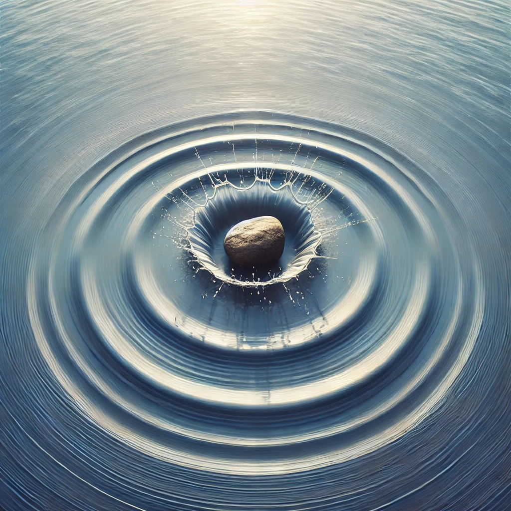

The connected pond, revisited.

**Coefficients are transformed.** Recall $\phi_{yx}=0$ but $a_{yx}=8/35$.

**Structure needs assumptions.** A valid decomposition does not prove its timing story.

**Disturbances move through the system.** One coefficient is only one part of that account.

| Next question | Later module |
| --- | --- |
| How does each variable respond over time to an identified disturbance? | **IRF · 12** |
| Which disturbances account for forecast-error variance at a given horizon? | **FEVD · 13** |